# K_Means Customer Segmentation

## Part 1. Exploratory Data Analysis

```python
# load libraries for data manipulation and index
import pandas as pd
import numpy as np
import matplotlib.pyplot as plt
import seaborn as sns
```

```python
# read the file in by using pandas and the file path

df = pd.read_csv("C:\\Users\\mrc16\\Downloads\\Online Retail Data (1).csv")
```

```python
#display the first 5 rows of the dataframe
df.head()
```

|  | InvoiceNo | StockCode | Description | Quantity | InvoiceDate | UnitPrice | CustomerID | Country |
| --- | --- | --- | --- | --- | --- | --- | --- | --- |
| 0 | 536365 | 85123A | WHITE HANGING HEART T-LIGHT HOLDER | 6 | 12/1/2010 8:26 | 2.55 | 17850.0 | United Kingdom |
| 1 | 536365 | 71053 | WHITE METAL LANTERN | 6 | 12/1/2010 8:26 | 3.39 | 17850.0 | United Kingdom |
| 2 | 536365 | 84406B | CREAM CUPID HEARTS COAT HANGER | 8 | 12/1/2010 8:26 | 2.75 | 17850.0 | United Kingdom |
| 3 | 536365 | 84029G | KNITTED UNION FLAG HOT WATER BOTTLE | 6 | 12/1/2010 8:26 | 3.39 | 17850.0 | United Kingdom |
| 4 | 536365 | 84029E | RED WOOLLY HOTTIE WHITE HEART. | 6 | 12/1/2010 8:26 | 3.39 | 17850.0 | United Kingdom |

```python
# display last 5 rows of the dataframe
df.tail()
```

|  | InvoiceNo | StockCode | Description | Quantity | InvoiceDate | UnitPrice | CustomerID | Country |
| --- | --- | --- | --- | --- | --- | --- | --- | --- |
| 541904 | 581587 | 22613 | PACK OF 20 SPACEBOY NAPKINS | 12 | 12/9/2011 12:50 | 0.85 | 12680.0 | France |
| 541905 | 581587 | 22899 | CHILDREN'S APRON DOLLY GIRL | 6 | 12/9/2011 12:50 | 2.10 | 12680.0 | France |
| 541906 | 581587 | 23254 | CHILDRENS CUTLERY DOLLY GIRL | 4 | 12/9/2011 12:50 | 4.15 | 12680.0 | France |
| 541907 | 581587 | 23255 | CHILDRENS CUTLERY CIRCUS PARADE | 4 | 12/9/2011 12:50 | 4.15 | 12680.0 | France |
| 541908 | 581587 | 22138 | BAKING SET 9 PIECE RETROSPOT | 3 | 12/9/2011 12:50 | 4.95 | 12680.0 | France |

```python
# number of rows by the number of columns

df.shape
```

```
(541909, 8)
```

```python
# summary of dataframe including data types and non- null values
df.info()
```

```
<class 'pandas.core.frame.DataFrame'>
RangeIndex: 541909 entries, 0 to 541908
Data columns (total 8 columns):
 #   Column       Non-Null Count   Dtype
---  ------       --------------   -----
 0   InvoiceNo    541909 non-null  object
 1   StockCode    541909 non-null  object
 2   Description  540455 non-null  object
 3   Quantity     541909 non-null  int64
 4   InvoiceDate  541909 non-null  object
 5   UnitPrice    541909 non-null  float64
 6   CustomerID   406829 non-null  float64
 7   Country      541909 non-null  object
dtypes: float64(2), int64(1), object(5)
memory usage: 33.1+ MB
```

```python
# basic statistical summary of numeric variables
df.describe()
```

|  | Quantity | UnitPrice | CustomerID |
| --- | --- | --- | --- |
| count | 541909.000000 | 541909.000000 | 406829.000000 |
| mean | 9.552250 | 4.611114 | 15287.690570 |
| std | 218.081158 | 96.759853 | 1713.600303 |
| min | -80995.000000 | -11062.060000 | 12346.000000 |
| 25% | 1.000000 | 1.250000 | 13953.000000 |
| 50% | 3.000000 | 2.080000 | 15152.000000 |
| 75% | 10.000000 | 4.130000 | 16791.000000 |
| max | 80995.000000 | 38970.000000 | 18287.000000 |

```python
# summary of the
(df.describe(include ='object'))
```

|  | InvoiceNo | StockCode | Description | InvoiceDate | Country |
| --- | --- | --- | --- | --- | --- |
| count | 541909 | 541909 | 540455 | 541909 | 541909 |
| unique | 25900 | 4070 | 4223 | 23260 | 38 |
| top | 573585 | 85123A | WHITE HANGING HEART T-LIGHT HOLDER | 10/31/2011 14:41 | United Kingdom |
| freq | 1114 | 2313 | 2369 | 1114 | 495478 |

```python
# check for null values
pd.isnull(df).sum()
```

```
InvoiceNo           0
StockCode           0
Description      1454
Quantity            0
InvoiceDate         0
UnitPrice           0
CustomerID     135080
Country             0
dtype: int64
```

```python
# current columns
df.columns
```

```
Index(['InvoiceNo', 'StockCode', 'Description', 'Quantity', 'InvoiceDate',
       'UnitPrice', 'CustomerID', 'Country'],
      dtype='object')
```

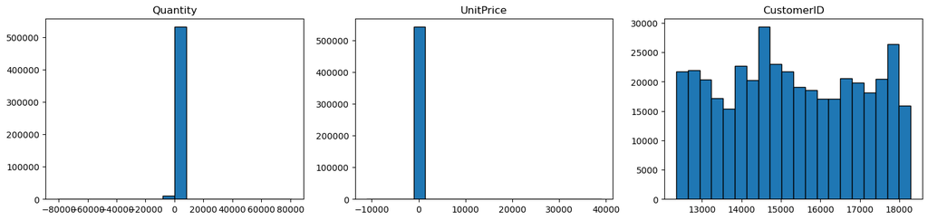

```python
# Generates histograms for all numeric columns, neatly spaced
df.hist(figsize=(15, 10), layout=(3, 3), bins=20, edgecolor='black', grid=False)

plt.tight_layout() # Ensures labels and titles don't overlap
plt.show()
```

```python
# the histograms show there are some outliers
print("Negative values count:", (df['UnitPrice'] < 0).sum())
```

```
Negative values count: 2
```

```python
# large neg quantity values Red Flag
print("Negative values count:", (df['Quantity'] < 0).sum())
```

```
Negative values count: 10624
```

```python
# change InvoiceDate to datetime proper format
df['InvoiceDate'] = pd.to_datetime(df['InvoiceDate'])
```

```python
# continue formatting date InvoiceDate2 is short date fotm

df['InvoiceDate2'] = df['InvoiceDate'].dt.strftime('%d/%m/%y')
```

```python
df.columns
```

```
Index(['InvoiceNo', 'StockCode', 'Description', 'Quantity', 'InvoiceDate',
       'UnitPrice', 'CustomerID', 'Country', 'InvoiceDate2'],
      dtype='object')
```

```python
df['InvoiceDate2'] = pd.to_datetime(df['InvoiceDate2']).dt.normalize()
```

```python
# redo info to see if date was successfully changed
df.info()
```

```
<class 'pandas.core.frame.DataFrame'>
RangeIndex: 541909 entries, 0 to 541908
Data columns (total 9 columns):
 #   Column        Non-Null Count   Dtype
---  ------        --------------   -----
 0   InvoiceNo     541909 non-null  object
 1   StockCode     541909 non-null  object
 2   Description   540455 non-null  object
 3   Quantity      541909 non-null  int64
 4   InvoiceDate   541909 non-null  datetime64[ns]
 5   UnitPrice     541909 non-null  float64
 6   CustomerID    406829 non-null  float64
 7   Country       541909 non-null  object
 8   InvoiceDate2  541909 non-null  datetime64[ns]
dtypes: datetime64[ns](2), float64(2), int64(1), object(4)
memory usage: 37.2+ MB
```

```python
df.Country.unique()
```

```
array(['United Kingdom', 'France', 'Australia', 'Netherlands', 'Germany',
       'Norway', 'EIRE', 'Switzerland', 'Spain', 'Poland', 'Portugal',
       'Italy', 'Belgium', 'Lithuania', 'Japan', 'Iceland',
       'Channel Islands', 'Denmark', 'Cyprus', 'Sweden', 'Austria',
       'Israel', 'Finland', 'Bahrain', 'Greece', 'Hong Kong', 'Singapore',
       'Lebanon', 'United Arab Emirates', 'Saudi Arabia',
       'Czech Republic', 'Canada', 'Unspecified', 'Brazil', 'USA',
       'European Community', 'Malta', 'RSA'], dtype=object)
```

```python
df.Description.nunique()
```

```
4223
```

```python
df['Country'].nunique()
```

```
38
```

```python
df['Country'].value_counts()
```

```
Country
United Kingdom          495478
Germany                   9495
France                    8557
EIRE                      8196
Spain                     2533
Netherlands               2371
Belgium                   2069
Switzerland               2002
Portugal                  1519
Australia                 1259
Norway                    1086
Italy                      803
Channel Islands            758
Finland                    695
Cyprus                     622
Sweden                     462
Unspecified                446
Austria                    401
Denmark                    389
Japan                      358
Poland                     341
Israel                     297
USA                        291
Hong Kong                  288
Singapore                  229
Iceland                    182
Canada                     151
Greece                     146
Malta                      127
United Arab Emirates        68
European Community          61
RSA                         58
Lebanon                     45
Lithuania                   35
Brazil                      32
Czech Republic              30
Bahrain                     19
Saudi Arabia                10
Name: count, dtype: int64
```

#### This shows that both Unit Price and CustomerID have issues CustomerID has %24.93 missing values that must be removed at this time. If the data was more recent and a better idea of customer behavior could be imputed that may possibly be an option, at this time both the CustomerID values and the 2 negative Unit Price values must be removed.

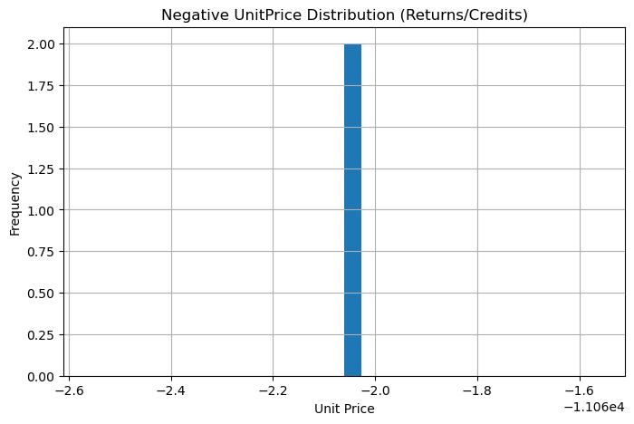

```python
### Unit price contains 2 very large negative values -11062.06 * 2 is the value
df_neg = df[df['UnitPrice'] < 0]

plt.figure(figsize=(8,5))
df_neg['UnitPrice'].hist(bins=30)

plt.title("Negative UnitPrice Distribution (Returns/Credits)")
plt.xlabel("Unit Price")
plt.ylabel("Frequency")
plt.show()
```

```python
print("Negative values count:", (df['UnitPrice'] < 0).sum())
```

```
Negative values count: 2
```

```python
df_neg = df[df['UnitPrice'] < 0]
```

```python
df_neg['UnitPrice'].value_counts()
```

```
UnitPrice
-11062.06    2
Name: count, dtype: int64
```

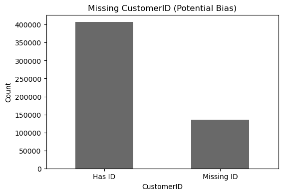

```python
# Count missing vs not missing
missing_counts = df['CustomerID'].isna().value_counts()

plt.figure(figsize=(6,4))
missing_counts.plot(kind='bar', color = 'dimgray')

plt.title("Missing CustomerID (Potential Bias)")
plt.xticks([0,1], ['Has ID', 'Missing ID'], rotation=0)
plt.ylabel("Count")
plt.show()
```

```python
missing_pct = df['CustomerID'].isna().mean() * 100
print(f"Percentage of missing CustomerID: {missing_pct:.2f}%")
```

```
Percentage of missing CustomerID: 24.93%
```

### Clean the data frame to run visuals and create RFM model...Variables that need to be cleaned before moving on to RFM are UnitPrice to remove negatives, CustomerID to remove missing values, Total Spend must be created to create RFM model and lastly the Date must be in Date Time format

```python
# check for null values
pd.isnull(df).sum()
```

```
InvoiceNo            0
StockCode            0
Description       1454
Quantity             0
InvoiceDate          0
UnitPrice            0
CustomerID      135080
Country              0
InvoiceDate2         0
dtype: int64
```

```python
# check for null values
pd.isnull(df).sum()
```

```
InvoiceNo            0
StockCode            0
Description       1454
Quantity             0
InvoiceDate          0
UnitPrice            0
CustomerID      135080
Country              0
InvoiceDate2         0
dtype: int64
```

```python
# Check missing CustomerID values before cleaning
print(df["CustomerID"].isna().sum())
print(df["CustomerID"].unique()[:20])
```

```
135080
[17850. 13047. 12583. 13748. 15100. 15291. 14688. 17809. 15311. 14527.
 16098. 18074. 17420. 16029. 16250. 12431. 17511. 17548. 13705. 13747.]
```

```python
import numpy as np

# Standardize CustomerID column
df["CustomerID"] = df["CustomerID"].replace(["nan", "NaN", "None", "", " "], np.nan)

# Drop missing CustomerID rows
df = df.dropna(subset=["CustomerID"]).copy()

# Optional: convert CustomerID to clean string format
df["CustomerID"] = df["CustomerID"].astype(float).astype(int).astype(str)

# Confirm they are gone
print(df["CustomerID"].isna().sum())
print(df.shape)
```

```
0
(406829, 9)
```

```python
# Drop transactions without CustomerID because customer-level segmentation requires a valid customer identifier
df = df.dropna(subset=["CustomerID"]).copy()

# Convert CustomerID to string or integer for cleaner grouping
df["CustomerID"] = df["CustomerID"].astype(int).astype(str)
```

```python
print(df.shape)

print(df["CustomerID"].isna().sum())

print(df["CustomerID"].nunique())
```

```
(406829, 9)
0
4372
```

```python
# Clean the data to start again to run the visuals
import pandas as pd
import numpy as np
import matplotlib.pyplot as plt

# Copy to avoid overwriting
df_clean = df.copy()

# Convert date
df_clean['InvoiceDate'] = pd.to_datetime(df_clean['InvoiceDate'], errors='coerce')

# Convert CustomerID to numeric (handles weird values)
df_clean['CustomerID'] = pd.to_numeric(df_clean['CustomerID'], errors='coerce')

# Create Total Spend
df_clean['TotalSpend'] = df_clean['Quantity'] * df_clean['UnitPrice']

# Remove clearly bad values for modeling/visualization
df_clean = df_clean[
    (df_clean['UnitPrice'] > 0) &
    (df_clean['Quantity'] > 0)
]
```

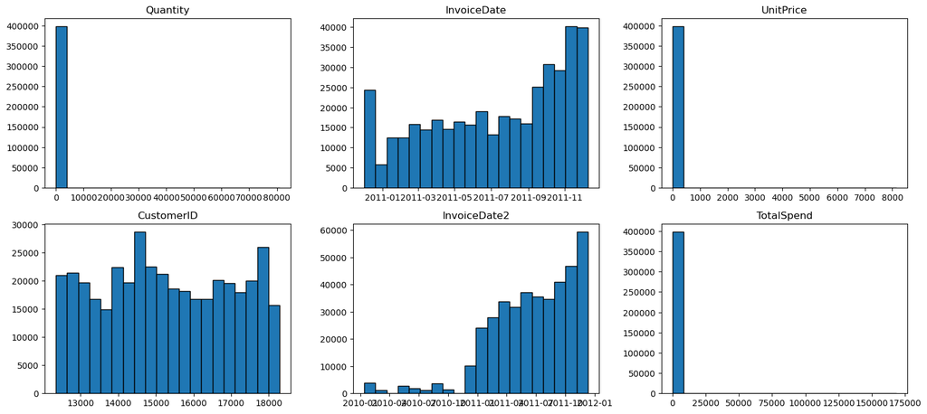

```python
# Generates histograms for all numeric columns, neatly spaced
df_clean.hist(figsize=(15, 10), layout=(3, 3), bins=20, edgecolor='black', grid=False)

plt.tight_layout() # Ensures labels and titles don't overlap
plt.show()
```

```python
df['CustomerID'].info()
```

```
<class 'pandas.core.series.Series'>
Index: 406829 entries, 0 to 541908
Series name: CustomerID
Non-Null Count   Dtype
--------------   -----
406829 non-null  object
dtypes: object(1)
memory usage: 6.2+ MB
```

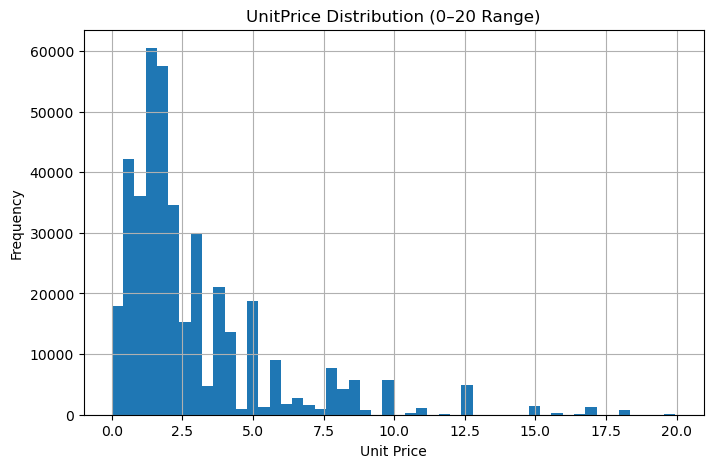

```python
df_vis = df[(df['UnitPrice'] > 0) & (df['UnitPrice'] < 20)]

plt.figure(figsize=(8,5))
df_vis['UnitPrice'].hist(bins=50)

plt.title("UnitPrice Distribution (0–20 Range)")
plt.xlabel("Unit Price")
plt.ylabel("Frequency")
plt.show()
```

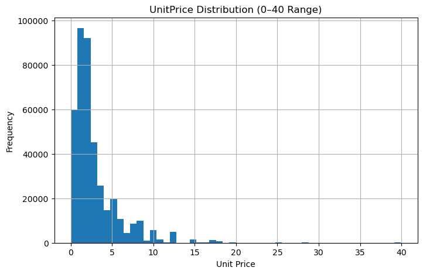

```python
df_vis = df[(df['UnitPrice'] > 0) & (df['UnitPrice'] < 40)]

plt.figure(figsize=(8,5))
df_vis['UnitPrice'].hist(bins=50)

plt.title("UnitPrice Distribution (0–40 Range)")
plt.xlabel("Unit Price")
plt.ylabel("Frequency")
plt.show()
```

#### The neg unit price have been removed. This and the large amount of CustomerID values that were removed are two of many reasons the organization must continue toi improve their data governace policies and procedures

[figure not shown]

```python
df_neg = df[df['UnitPrice'] < 0]

plt.figure(figsize=(8,5))
df_neg['UnitPrice'].hist(bins=30)

plt.title("Negative UnitPrice Distribution (Returns/Credits)")
plt.xlabel("Unit Price")
plt.ylabel("Frequency")
plt.show()
```

```python
print("Negative values count:", (df['UnitPrice'] < 0).sum())
```

```
Negative values count: 0
```

```python
df_clean.info()
```

```
<class 'pandas.core.frame.DataFrame'>
Index: 397884 entries, 0 to 541908
Data columns (total 10 columns):
 #   Column        Non-Null Count   Dtype
---  ------        --------------   -----
 0   InvoiceNo     397884 non-null  object
 1   StockCode     397884 non-null  object
 2   Description   397884 non-null  object
 3   Quantity      397884 non-null  int64
 4   InvoiceDate   397884 non-null  datetime64[ns]
 5   UnitPrice     397884 non-null  float64
 6   CustomerID    397884 non-null  int64
 7   Country       397884 non-null  object
 8   InvoiceDate2  397884 non-null  datetime64[ns]
 9   TotalSpend    397884 non-null  float64
dtypes: datetime64[ns](2), float64(2), int64(2), object(4)
memory usage: 33.4+ MB
```

## RFM Customer Segmentation

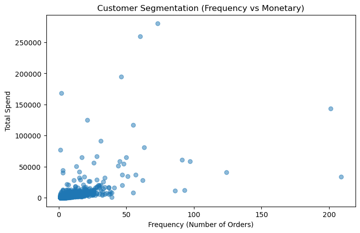

```python
# Aggregate to customer level
rfm = df_clean.groupby('CustomerID').agg({
    'InvoiceDate': lambda x: (df_clean['InvoiceDate'].max() - x.max()).days,
    'InvoiceNo': 'nunique',
    'TotalSpend': 'sum'
})

rfm.columns = ['Recency', 'Frequency', 'Monetary']

# Plot Frequency vs Monetary
plt.figure(figsize=(8,5))
plt.scatter(rfm['Frequency'], rfm['Monetary'], alpha=0.5)

plt.title("Customer Segmentation (Frequency vs Monetary)")
plt.xlabel("Frequency (Number of Orders)")
plt.ylabel("Total Spend")
plt.show()
```

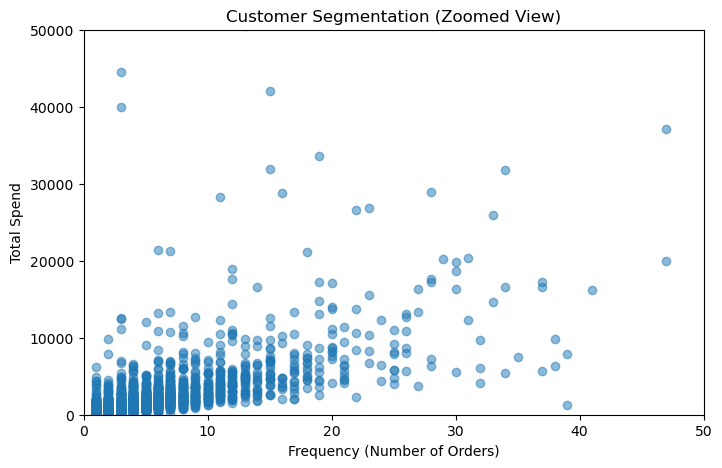

```python
plt.figure(figsize=(8,5))
plt.scatter(rfm['Frequency'], rfm['Monetary'], alpha=0.5)

# Zoom in
plt.xlim(0, 50)
plt.ylim(0, 50000)

plt.title("Customer Segmentation (Zoomed View)")
plt.xlabel("Frequency (Number of Orders)")
plt.ylabel("Total Spend")
plt.show()
```

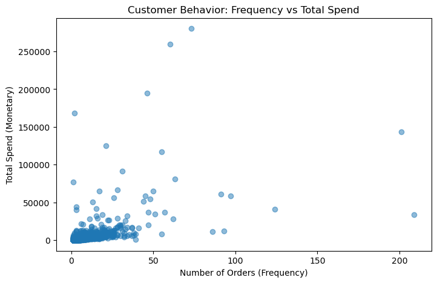

```python
# Create Total Spend
df_clean['TotalSpend'] = df_clean['Quantity'] * df_clean['UnitPrice']

# Aggregate by customer
customer_data = df_clean.groupby('CustomerID').agg({
    'InvoiceNo': 'nunique',   # Frequency
    'TotalSpend': 'sum'       # Monetary
})

# Plot
plt.figure(figsize=(8,5))
plt.scatter(customer_data['InvoiceNo'], customer_data['TotalSpend'], alpha=0.5)

plt.title("Customer Behavior: Frequency vs Total Spend")
plt.xlabel("Number of Orders (Frequency)")
plt.ylabel("Total Spend (Monetary)")
plt.show()
```

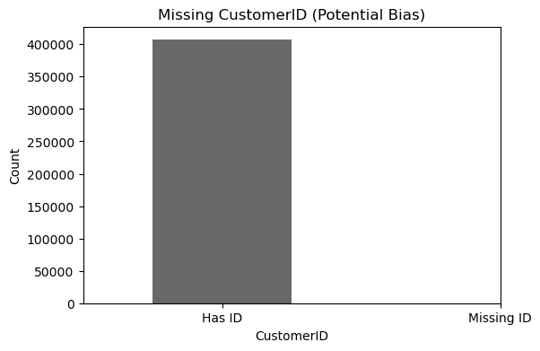

```python
# Count missing vs not missing
missing_counts = df['CustomerID'].isna().value_counts()

plt.figure(figsize=(6,4))
missing_counts.plot(kind='bar', color = 'dimgray')

plt.title("Missing CustomerID (Potential Bias)")
plt.xticks([0,1], ['Has ID', 'Missing ID'], rotation=0)
plt.ylabel("Count")
plt.show()
```

#### For Recency, Frequency, Monetary. the date has to be properly formated to understand date since last purchase

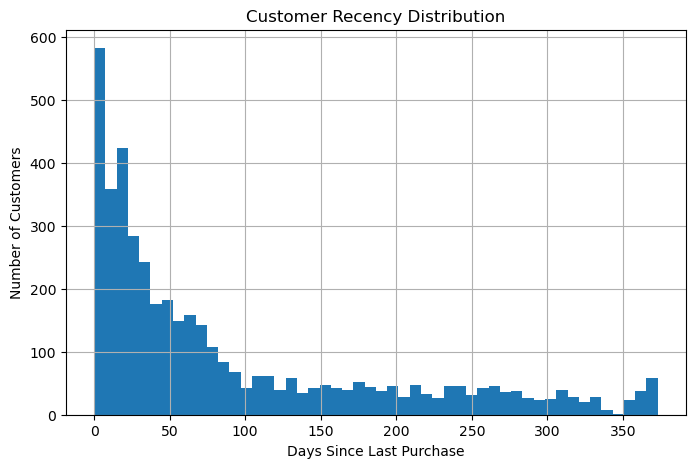

```python
# Make sure date is correct
df_clean['InvoiceDate'] = pd.to_datetime(df_clean['InvoiceDate'])

# Get most recent date in dataset
snapshot_date = df_clean['InvoiceDate'].max()

# Calculate recency per customer
recency = df_clean.groupby('CustomerID')['InvoiceDate'].max().apply(lambda x: (snapshot_date - x).days)

# Plot
plt.figure(figsize=(8,5))
recency.hist(bins=50)

plt.title("Customer Recency Distribution")
plt.xlabel("Days Since Last Purchase")
plt.ylabel("Number of Customers")
plt.show()
```

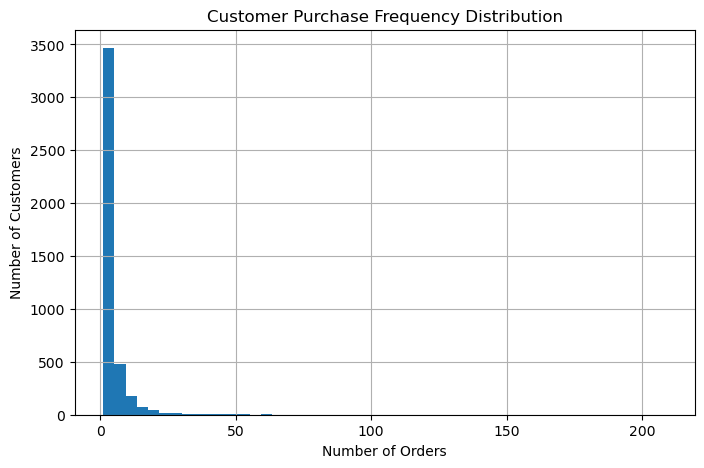

```python
# Frequency = number of unique invoices per customer
frequency = df_clean.groupby('CustomerID')['InvoiceNo'].nunique()

# Plot
plt.figure(figsize=(8,5))
frequency.hist(bins=50)

plt.title("Customer Purchase Frequency Distribution")
plt.xlabel("Number of Orders")
plt.ylabel("Number of Customers")
plt.show()
```

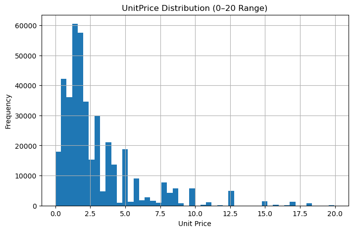

```python
df_vis = df[(df['UnitPrice'] > 0) & (df['UnitPrice'] < 20)]

plt.figure(figsize=(8,5))
df_vis['UnitPrice'].hist(bins=50)

plt.title("UnitPrice Distribution (0–20 Range)")
plt.xlabel("Unit Price")
plt.ylabel("Frequency")
plt.show()
```

```python
# create total spend
df_clean['TotalSpend'] = df_clean['Quantity'] * df_clean['UnitPrice']
```

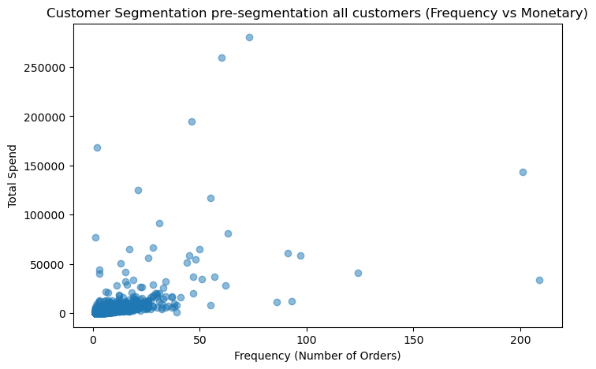

```python
# Aggregate to customer level
rfm = df_clean.groupby('CustomerID').agg({
    'InvoiceDate': lambda x: (df_clean['InvoiceDate'].max() - x.max()).days,
    'InvoiceNo': 'nunique',
    'TotalSpend': 'sum'
})

rfm.columns = ['Recency', 'Frequency', 'Monetary']

# Plot Frequency vs Monetary
plt.figure(figsize=(8,5))
plt.scatter(rfm['Frequency'], rfm['Monetary'], alpha=0.5)

plt.title("Customer Segmentation pre-segmentation all customers (Frequency vs Monetary)")
plt.xlabel("Frequency (Number of Orders)")
plt.ylabel("Total Spend")
plt.show()
```

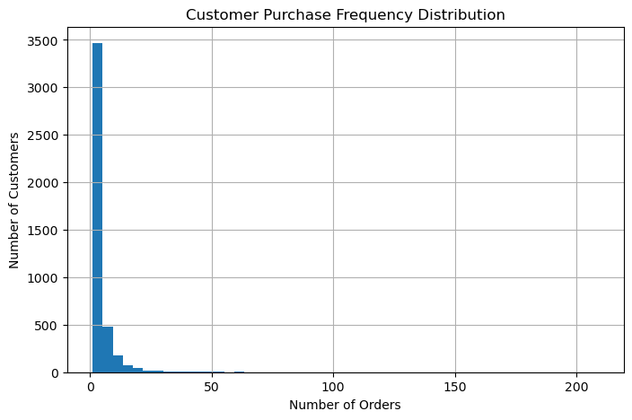

```python
# Frequency = number of unique invoices per customer
frequency = df_clean.groupby('CustomerID')['InvoiceNo'].nunique()

# Plot
plt.figure(figsize=(8,5))
frequency.hist(bins=50)

plt.title("Customer Purchase Frequency Distribution")
plt.xlabel("Number of Orders")
plt.ylabel("Number of Customers")
plt.show()
```

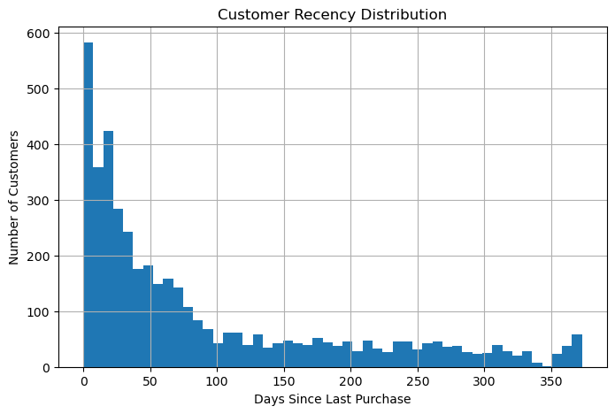

```python
# Make sure date is correct
df_clean['InvoiceDate'] = pd.to_datetime(df_clean['InvoiceDate'])

# Get most recent date in dataset
snapshot_date = df_clean['InvoiceDate'].max()

# Calculate recency per customer
recency = df_clean.groupby('CustomerID')['InvoiceDate'].max().apply(lambda x: (snapshot_date - x).days)

# Plot
plt.figure(figsize=(8,5))
recency.hist(bins=50)

plt.title("Customer Recency Distribution")
plt.xlabel("Days Since Last Purchase")
plt.ylabel("Number of Customers")
plt.show()
```

```python
from sklearn.preprocessing import StandardScaler
from sklearn.cluster import KMeans

# Scale
scaler = StandardScaler()
rfm_scaled = scaler.fit_transform(rfm[['Recency','Frequency','Monetary']])

# K-means
kmeans = KMeans(n_clusters=3, random_state=42)
rfm['Cluster'] = kmeans.fit_predict(rfm_scaled)
```

#### The Elbow method is used to help decide number of clusters at first I used 4 but realized I did not properly drop the CustomerID values that were missing because dropna did not work and I failed to check this, this time I will try 3 first and then 4 if neccessary. As you can see it seems like the point of diminishing returns is 3, but 4 may be a choice.

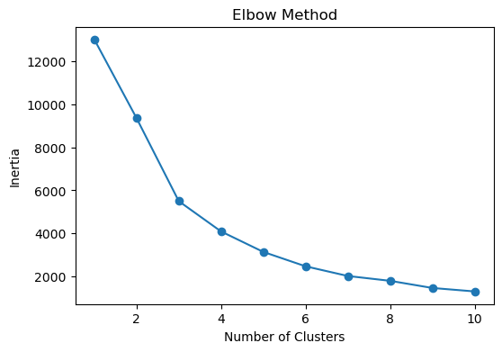

```python
from sklearn.cluster import KMeans
import matplotlib.pyplot as plt

inertia = []

K = range(1, 11)

for k in K:
    kmeans = KMeans(n_clusters=k, random_state=42)
    kmeans.fit(rfm_scaled)
    inertia.append(kmeans.inertia_)

plt.figure(figsize=(6,4))
plt.plot(range(1,11), inertia, marker='o')
plt.title('Elbow Method')
plt.xlabel('Number of Clusters')
plt.ylabel('Inertia')
plt.show()
```

```python
rfm.groupby('Cluster')[['Recency','Frequency','Monetary']].mean()
```

| Cluster | Recency | Frequency | Monetary |
| --- | --- | --- | --- |
| 0 | 39.983906 | 4.852677 | 2012.111620 |
| 1 | 245.023788 | 1.582800 | 631.141410 |
| 2 | 6.142857 | 80.214286 | 122888.407143 |

```python
# Make sure date is correct
df_clean['InvoiceDate'] = pd.to_datetime(df_clean['InvoiceDate'])

# Snapshot date
snapshot_date = df_clean['InvoiceDate'].max()

# Create TotalSpend
df_clean['TotalSpend'] = df_clean['Quantity'] * df_clean['UnitPrice']

# Build RFM
rfm = df_clean.groupby('CustomerID').agg({
    'InvoiceDate': lambda x: (snapshot_date - x.max()).days,
    'InvoiceNo': 'nunique',
    'TotalSpend': 'sum'
})

rfm.columns = ['Recency', 'Frequency', 'Monetary']

rfm.head()
```

| CustomerID | Recency | Frequency | Monetary |
| --- | --- | --- | --- |
| 12346 | 325 | 1 | 77183.60 |
| 12347 | 1 | 7 | 4310.00 |
| 12348 | 74 | 4 | 1797.24 |
| 12349 | 18 | 1 | 1757.55 |
| 12350 | 309 | 1 | 334.40 |

```python
# K-means
kmeans = KMeans(n_clusters=4, random_state=42)
rfm['Cluster'] = kmeans.fit_predict(rfm_scaled)
rfm.groupby('Cluster')[['Recency','Frequency','Monetary']].mean()
```

| Cluster | Recency | Frequency | Monetary |
| --- | --- | --- | --- |
| 0 | 42.702685 | 3.682711 | 1359.049284 |
| 1 | 247.075914 | 1.552015 | 480.617480 |
| 2 | 6.384615 | 82.538462 | 127338.313846 |
| 3 | 14.500000 | 22.333333 | 12709.090490 |

```python
# Create RFM scores (1–4 scale)
rfm['R_score'] = pd.qcut(rfm['Recency'], 4, labels=[4,3,2,1])
rfm['F_score'] = pd.qcut(rfm['Frequency'].rank(method='first'), 4, labels=[1,2,3,4])
rfm['M_score'] = pd.qcut(rfm['Monetary'], 4, labels=[1,2,3,4])

# Combine into one score
rfm['RFM_Score'] = rfm['R_score'].astype(str) + rfm['F_score'].astype(str) + rfm['M_score'].astype(str)

rfm.head()
```

[output not shown]

```python
rfm.info()
```

[output not shown]

```python
def segment(row):
    if row['R_score'] == 4 and row['F_score'] == 4:
        return 'Best Customers'
    elif row['R_score'] >= 3 and row['F_score'] >= 3:
        return 'Loyal Customers'
    elif row['R_score'] <= 2 and row['F_score'] <= 2:
        return 'At Risk'
    else:
        return 'Average'

rfm['Segment'] = rfm.apply(segment, axis=1)

rfm['Segment'].value_counts()
```

```
Segment
At Risk            1504
Average            1311
Loyal Customers     914
Best Customers      609
Name: count, dtype: int64
```

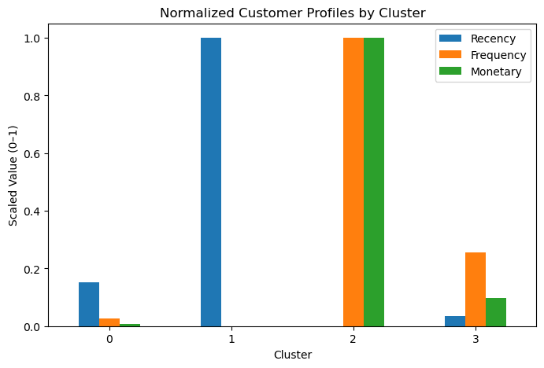

```python
cluster_summary = rfm.groupby('Cluster')[['Recency','Frequency','Monetary']].mean()

# Normalize for readability
from sklearn.preprocessing import MinMaxScaler
scaler = MinMaxScaler()
cluster_scaled = scaler.fit_transform(cluster_summary)

cluster_scaled_df = pd.DataFrame(
    cluster_scaled,
    columns=['Recency','Frequency','Monetary'],
    index=cluster_summary.index
)

cluster_scaled_df.plot(kind='bar', figsize=(8,5))

plt.title("Normalized Customer Profiles by Cluster")
plt.xlabel("Cluster")
plt.ylabel("Scaled Value (0–1)")
plt.xticks(rotation=0)
plt.legend()
plt.show()
```

```python
rfm['Segment'].value_counts()
```

```
Segment
At Risk            1504
Average            1311
Loyal Customers     914
Best Customers      609
Name: count, dtype: int64
```

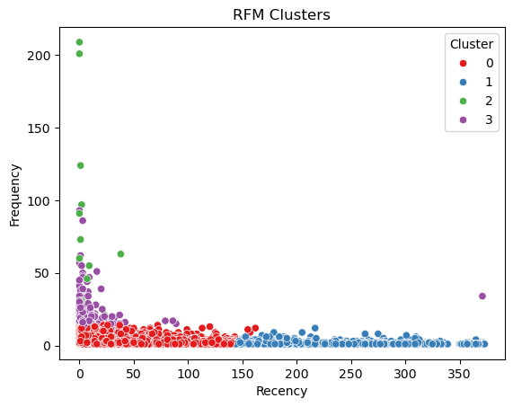

```python
import seaborn as sns

# Visualizing the clusters
sns.scatterplot(data=rfm, x='Recency', y='Frequency', hue='Cluster', palette='Set1')
plt.title('RFM Clusters')
plt.show()
```